# Data Exploration & Transformation – EDA

## Dataset Analysis Steps:

### 1. Import Libraries

### 2. Load & Display Sample Data

### 3. Dataset Stats (# of Rows & Columns)

### 4. Datatypes Identification

### 5. Isolate Numerical Columns

### 6. Convert Datatype: Float to Int (Optional)

### 7. Group Numerical Columns

### 8. Summary Statistics Numerical Columns

### 9. Isolate Categorical Columns

### 10. Convert Datatype: Object to Category

### 11. Group Categorical Columns

### 12. Summary Statistics Categorical Columns

### 13. Unique Values in Categorical Columns (Cardinality) - Data & Chart

### 1. Import Libraries

```python
import pandas as pd
import numpy as np
import matplotlib.pyplot as plt
import matplotlib.ticker as mtick
import seaborn as sns
import warnings
import scipy.stats as stats
import feature_engine.transformation as vt
import featuretools as ft
import statistics as stat
import statsmodels.api as sm
import scipy as sp
import xgboost
from math import sqrt
from scipy.stats import chi2_contingency
from scipy.stats import chi2
from scipy.stats import kurtosis, skew
from statsmodels.stats.multicomp import MultiComparison
from itertools import combinations
from statistics import mean
from sklearn import linear_model
from sklearn.impute import SimpleImputer
from sklearn.model_selection import train_test_split
from sklearn import preprocessing
from sklearn.preprocessing import MinMaxScaler
from sklearn.preprocessing import StandardScaler
from sklearn.preprocessing import OneHotEncoder
from sklearn.linear_model import LinearRegression
from sklearn.linear_model import Lasso
from sklearn.model_selection import RepeatedKFold
from sklearn.ensemble import RandomForestRegressor
from sklearn.metrics import mean_squared_error, r2_score, mean_absolute_error
from sklearn.tree import DecisionTreeRegressor
from sklearn.pipeline import Pipeline
from sklearn.preprocessing import StandardScaler
from sklearn.feature_selection import SelectFromModel
from sklearn.linear_model import LinearRegression
from sklearn.preprocessing import PolynomialFeatures
from sklearn.svm import SVR
from sklearn.utils import all_estimators
from sklearn.linear_model import SGDRegressor
from sklearn.linear_model import BayesianRidge
from sklearn.ensemble import GradientBoostingRegressor
from sklearn.kernel_ridge import KernelRidge
from sklearn.linear_model import ElasticNet
from sklearn.model_selection import GridSearchCV
from sklearn.model_selection import RandomizedSearchCV
from sklearn.metrics import mean_absolute_percentage_error
from feature_engine.encoding import RareLabelEncoder
from feature_engine.outliers import Winsorizer
from feature_engine.discretisation import DecisionTreeDiscretiser
from feature_engine.imputation import MeanMedianImputer
from xgboost.sklearn import XGBRegressor
from lightgbm import LGBMRegressor
from catboost import CatBoostRegressor


warnings.simplefilter(action="ignore", category=FutureWarning)

# Default setting to display all rows and columns without truncating.
pd.set_option('display.max_rows', None)
pd.set_option('display.max_columns', None)
pd.set_option('display.width', None)
pd.set_option('display.max_colwidth', 5000)
```

### 2. Load & Display Sample Data

Loading 2021 Stack overflow annual developer survey data. This data cleaned for EDA and feature engineering.

```python
data = pd.read_csv(r'C:\Users\mak01\Desktop\Mihir\Project\Data Science Portfolio\End to End DS Project\Data Scientist Roles in USA\Python Scripts  - Transformation Data\CSV Output\stackoverflow_data.csv')
data.head()
```

|  | response_id | state | state_code | education | seniority_level | compensation | avg_age | language_python | language_r | language_sql | language_bash_shell | language_java | language_javascript | language_html_css | platform_aws | platform_gcp | platform_azure |
| --- | --- | --- | --- | --- | --- | --- | --- | --- | --- | --- | --- | --- | --- | --- | --- | --- | --- |
| 0 | 63 | New York | NY | Bachelor | Mid-Senior level | 130000.0 | 30.0 | 1 | 0 | 1 | 0 | 1 | 1 | 1 | 1 | 0 | 1 |
| 1 | 88 | Maryland | MD | Doctorate | Entry Level | 100000.0 | 30.0 | 1 | 0 | 0 | 1 | 0 | 0 | 1 | 0 | 1 | 0 |
| 2 | 191 | Massachusetts | MA | Master | Mid-Senior level | 70000.0 | 30.0 | 1 | 0 | 0 | 0 | 1 | 1 | 0 | 1 | 0 | 0 |
| 3 | 433 | Pennsylvania | PA | Doctorate | Mid-Senior level | 90000.0 | 40.0 | 0 | 1 | 1 | 1 | 0 | 0 | 0 | 0 | 1 | 0 |
| 4 | 688 | Texas | TX | Bachelor | Mid-Senior level | 130000.0 | 40.0 | 0 | 0 | 1 | 0 | 1 | 1 | 1 | 0 | 0 | 1 |

### 3. Dataset Stats (# of Rows & Columns)

```python
# Get total number of rows.
print("Rows:" , len(data.index))

# Get total number of columns.
print("Columns:", len(data.columns))
```

```
Rows: 591
Columns: 17
```

### 4. Datatypes Identification

#### Data Description

response_id - Developer's response identification number on the survey

state - State of the developer

state_code - State code of the developer

education - Education of the developer

seniority_level - Level of experience in the field of Data Science

compensation - Salary of developer

avg_age - Approximate age of the developer

language_python - Codes in Python (0 - No & 1 - Yes)

language_r - Codes in R (0 - No & 1 - Yes)

language_sql - Codes in SQL (0 - No & 1 - Yes)

language_bash_shell - Codes in Bash/Shell (0 - No & 1 - Yes)

language_java - Codes in Java (0 - No & 1 - Yes)

language_javascript - Codes in Javascript (0 - No & 1 - Yes)

language_html_css - Codes in HTML/CSS (0 - No & 1 - Yes)

platform_aws - Uses AWS platform (0 - No & 1 - Yes)

platform_gcp - Uses GCP platform (0 - No & 1 - Yes)

platform_azure - Uses Azure platform (0 - No & 1 - Yes)

```python
# Provide datatype information of each column in the dataset.
data.info()
```

```
<class 'pandas.core.frame.DataFrame'>
RangeIndex: 591 entries, 0 to 590
Data columns (total 17 columns):
 #   Column               Non-Null Count  Dtype
---  ------               --------------  -----
 0   response_id          591 non-null    int64
 1   state                582 non-null    object
 2   state_code           582 non-null    object
 3   education            591 non-null    object
 4   seniority_level      591 non-null    object
 5   compensation         591 non-null    float64
 6   avg_age              591 non-null    float64
 7   language_python      591 non-null    int64
 8   language_r           591 non-null    int64
 9   language_sql         591 non-null    int64
 10  language_bash_shell  591 non-null    int64
 11  language_java        591 non-null    int64
 12  language_javascript  591 non-null    int64
 13  language_html_css    591 non-null    int64
 14  platform_aws         591 non-null    int64
 15  platform_gcp         591 non-null    int64
 16  platform_azure       591 non-null    int64
dtypes: float64(2), int64(11), object(4)
memory usage: 78.6+ KB
```

### 5. Isolate Numerical Columns

Segregating numerical columns for EDA and feature engineering.

```python
# Find all the numerical columns.
numerical_cols = data.select_dtypes(include=['int64', 'float64']).columns
data[numerical_cols].dtypes
```

```
response_id              int64
compensation           float64
avg_age                float64
language_python          int64
language_r               int64
language_sql             int64
language_bash_shell      int64
language_java            int64
language_javascript      int64
language_html_css        int64
platform_aws             int64
platform_gcp             int64
platform_azure           int64
dtype: object
```

### 6. Convert Datatype: Float to Int (Optional)

Converting all columns into int datatype to make it easier for EDA & feature engineering.

```python
# Convert all float objects to int datatype.
data[numerical_cols] = data[numerical_cols].apply(lambda x: x.astype(int))
data[numerical_cols].dtypes
```

```
response_id            int32
compensation           int32
avg_age                int32
language_python        int32
language_r             int32
language_sql           int32
language_bash_shell    int32
language_java          int32
language_javascript    int32
language_html_css      int32
platform_aws           int32
platform_gcp           int32
platform_azure         int32
dtype: object
```

### 7. Group Numerical Columns

Grouping all numerical columns for EDA and feature engineering.

```python
# Group all numerical columns.
numerical_cols = ['compensation', 'avg_age']
numerical_cols
```

```
['compensation', 'avg_age']
```

### 8. Summary Statistics Numerical Columns

Get high level statistics of all numerical columns.

```python
# Get summary statistics for numerical columns.
data.describe()
```

|  | response_id | compensation | avg_age | language_python | language_r | language_sql | language_bash_shell | language_java | language_javascript | language_html_css | platform_aws | platform_gcp | platform_azure |
| --- | --- | --- | --- | --- | --- | --- | --- | --- | --- | --- | --- | --- | --- |
| count | 591.000000 | 591.000000 | 591.000000 | 591.000000 | 591.000000 | 591.000000 | 591.000000 | 591.000000 | 591.000000 | 591.000000 | 591.000000 | 591.000000 | 591.000000 |
| mean | 42981.170897 | 136556.854484 | 34.947547 | 0.871404 | 0.431472 | 0.597293 | 0.451777 | 0.551607 | 0.470389 | 0.406091 | 0.593909 | 0.279188 | 0.248731 |
| std | 26411.738567 | 55071.570179 | 10.122753 | 0.335035 | 0.495701 | 0.490858 | 0.498091 | 0.497751 | 0.499545 | 0.491518 | 0.491518 | 0.448980 | 0.432644 |
| min | 63.000000 | 50000.000000 | 0.000000 | 0.000000 | 0.000000 | 0.000000 | 0.000000 | 0.000000 | 0.000000 | 0.000000 | 0.000000 | 0.000000 | 0.000000 |
| 25% | 19362.500000 | 96500.000000 | 30.000000 | 1.000000 | 0.000000 | 0.000000 | 0.000000 | 0.000000 | 0.000000 | 0.000000 | 0.000000 | 0.000000 | 0.000000 |
| 50% | 47266.000000 | 125000.000000 | 30.000000 | 1.000000 | 0.000000 | 1.000000 | 0.000000 | 1.000000 | 0.000000 | 0.000000 | 1.000000 | 0.000000 | 0.000000 |
| 75% | 67263.000000 | 170000.000000 | 40.000000 | 1.000000 | 1.000000 | 1.000000 | 1.000000 | 1.000000 | 1.000000 | 1.000000 | 1.000000 | 1.000000 | 0.000000 |
| max | 83437.000000 | 300000.000000 | 65.000000 | 1.000000 | 1.000000 | 1.000000 | 1.000000 | 1.000000 | 1.000000 | 1.000000 | 1.000000 | 1.000000 | 1.000000 |

### 9. Isolate Categorical Columns

Segregating categorical columns for EDA and feature engineering.

```python
# Find all categorical columns.
categorical_cols = data.select_dtypes(include=['object']).columns
data[categorical_cols].dtypes
```

```
state              object
state_code         object
education          object
seniority_level    object
dtype: object
```

### 10. Group Categorical Columns

Grouping all categorical columns for EDA and feature engineering.

```python
# Group all categorical columns.
categorical_cols = ['state_code', 'education', 'seniority_level', 'language_python', 'language_r',
                    'language_sql', 'language_bash_shell', 'language_java', 'language_javascript',
                    'language_html_css', 'platform_aws', 'platform_gcp', 'platform_azure']
categorical_cols
```

```
['state_code',
 'education',
 'seniority_level',
 'language_python',
 'language_r',
 'language_sql',
 'language_bash_shell',
 'language_java',
 'language_javascript',
 'language_html_css',
 'platform_aws',
 'platform_gcp',
 'platform_azure']
```

### 11. Convert Datatype: Object to Category

Converting all columns into category datatype for make it easier for EDA & feature engineering.

```python
# Convert all object datatype to category datatype.
data[categorical_cols] = data[categorical_cols].apply(lambda x: x.astype('category'))
data[categorical_cols].dtypes
```

```
state_code             category
education              category
seniority_level        category
language_python        category
language_r             category
language_sql           category
language_bash_shell    category
language_java          category
language_javascript    category
language_html_css      category
platform_aws           category
platform_gcp           category
platform_azure         category
dtype: object
```

### 12. Summary Statistics Categorical Columns

Get high level statistics of all categorical columns.

```python
# Get summary statistics for categorical columns.
data.describe(include='category')
```

|  | state_code | education | seniority_level | language_python | language_r | language_sql | language_bash_shell | language_java | language_javascript | language_html_css | platform_aws | platform_gcp | platform_azure |
| --- | --- | --- | --- | --- | --- | --- | --- | --- | --- | --- | --- | --- | --- |
| count | 582 | 591 | 591 | 591 | 591 | 591 | 591 | 591 | 591 | 591 | 591 | 591 | 591 |
| unique | 43 | 4 | 3 | 2 | 2 | 2 | 2 | 2 | 2 | 2 | 2 | 2 | 2 |
| top | CA | Master | Mid-Senior level | 1 | 0 | 1 | 0 | 1 | 0 | 0 | 1 | 0 | 0 |
| freq | 69 | 215 | 411 | 515 | 336 | 353 | 324 | 326 | 313 | 351 | 351 | 426 | 444 |

### 13. Unique Values in Categorical Columns (Cardinality) - Data & Chart

View all the unique values for all categorical columns.

```
state_code
['NY', 'MD', 'MA', 'PA', 'TX', ..., 'NH', 'DE', 'IN', 'SD', 'AK']
Length: 44
Categories (43, object): ['AK', 'AL', 'AZ', 'CA', ..., 'VT', 'WA', 'WI', 'WV']
state_code unique count:  43


education
['Bachelor', 'Doctorate', 'Master', 'Other']
Categories (4, object): ['Bachelor', 'Doctorate', 'Master', 'Other']
education unique count:  4


seniority_level
['Mid-Senior level', 'Entry Level', 'Associate']
Categories (3, object): ['Associate', 'Entry Level', 'Mid-Senior level']
seniority_level unique count:  3


language_python
[1, 0]
Categories (2, int64): [0, 1]
language_python unique count:  2


language_r
[0, 1]
Categories (2, int64): [0, 1]
language_r unique count:  2


language_sql
[1, 0]
Categories (2, int64): [0, 1]
language_sql unique count:  2


language_bash_shell
[0, 1]
Categories (2, int64): [0, 1]
```

[output cut: 22 more lines]

```
[1, 0]
Categories (2, int64): [0, 1]
platform_aws unique count:  2


platform_gcp
[0, 1]
Categories (2, int64): [0, 1]
platform_gcp unique count:  2


platform_azure
[1, 0]
Categories (2, int64): [0, 1]
platform_azure unique count:  2
```

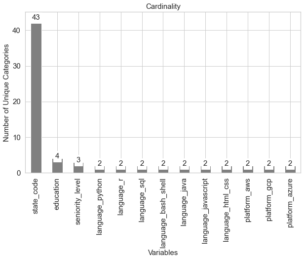

```python
# Provide unique count values for each categorical column.
for col in categorical_cols:
    print(col)
    i = data[col].unique()
    print(i)
    print(col, 'unique count: ', data[col].nunique())
    print('\n')

# Bar chart for number of missing values for all columns.
## Value label function.
def add_value_label(x_list,y_list):
    for i in range(len(x_list)):
        plt.text(i,y_list[i],y_list[i], ha='center', fontsize = 15, bbox = dict(facecolor = 'white', alpha =1.0))

## Declare variable for x and y axis.
variables = data[categorical_cols].columns
number_of_unique_values = data[categorical_cols].nunique()

## Plotting cardinality of categorical column.
data[categorical_cols].nunique().plot.bar(figsize=(10,6), color= 'grey', fontsize = 15)

## Attributes of bar chart.
plt.ylabel('Number of Unique Categories', fontsize = 15)
plt.xlabel('Variables', fontsize = 15)
plt.title('Cardinality', fontsize = 15)

## Instantiate value label function.
add_value_label(variables, number_of_unique_values)
```

## Rare Categories Steps:

### 1. Count of Rare Categories in Categorical Columns - Data & Chart

### 2. % of Rare Categories in Categorical Columns - Data & Chart

### 1. Count of Rare Categories in Categorical Columns - Data & Chart

```
state_code
CA    69
MA    42
TX    41
NY    37
WA    33
CO    29
VA    27
MD    25
IL    21
OH    21
NC    20
GA    19
OR    18
PA    17
NJ    14
MI    13
FL    12
DC    12
UT    11
AZ    10
MO    10
TN     9
CT     8
MN     8
WI     6
NM     6
LA     5
KS     5
AL     4
IN     4
ME     3
VT     3
KY     3
ID     3
SC     3
IA     3
ND     2
AK     1
SD     1
NH     1
MT     1
DE     1
WV     1
Name: state_code, dtype: int64
state_code total count:  582
```

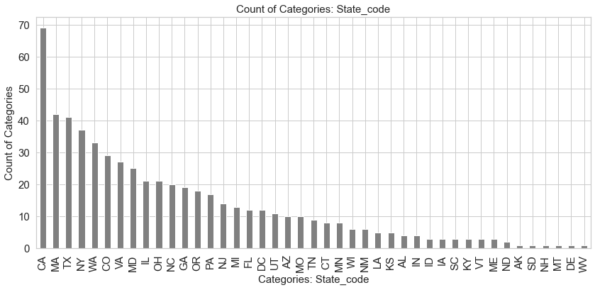

```
education
Master       215
Bachelor     212
Doctorate    119
Other         45
Name: education, dtype: int64
education total count:  591
```

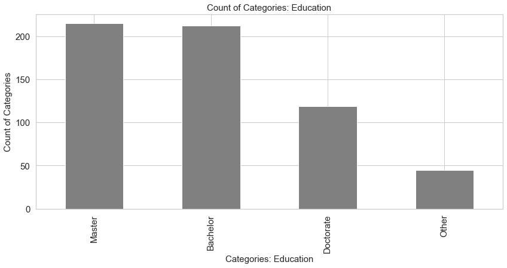

```
seniority_level
Mid-Senior level    411
Entry Level         141
Associate            39
Name: seniority_level, dtype: int64
seniority_level total count:  591
```

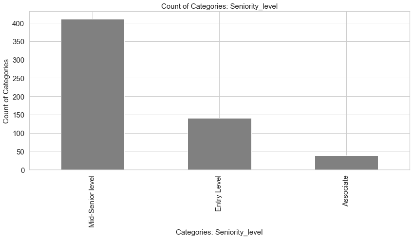

```
language_python
1    515
0     76
Name: language_python, dtype: int64
language_python total count:  591
```

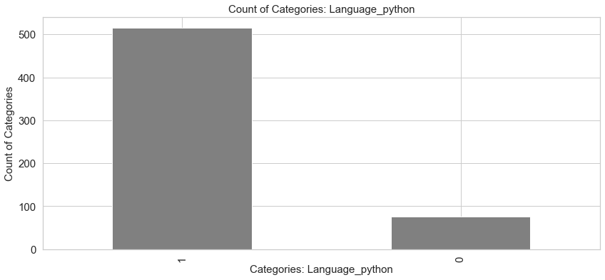

```
language_r
0    336
1    255
Name: language_r, dtype: int64
language_r total count:  591
```

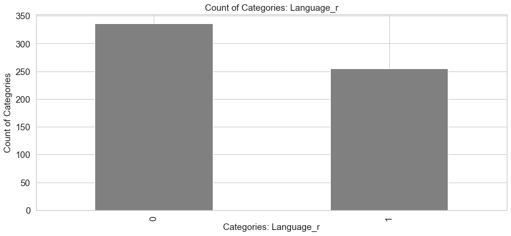

```
language_sql
1    353
0    238
Name: language_sql, dtype: int64
language_sql total count:  591
```

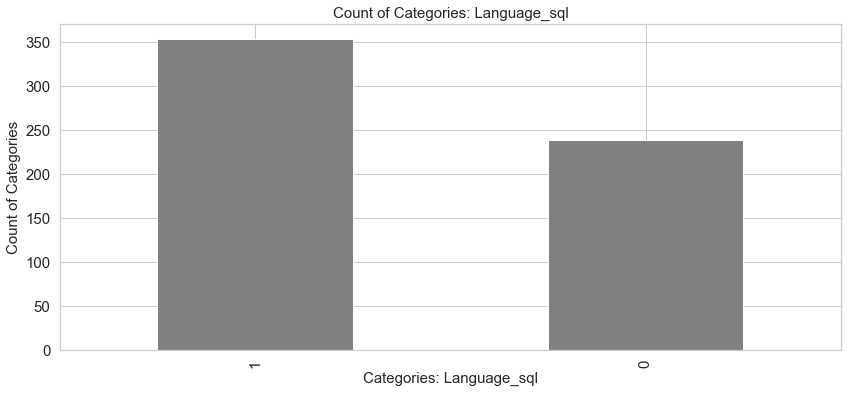

```
language_bash_shell
0    324
1    267
Name: language_bash_shell, dtype: int64
language_bash_shell total count:  591
```

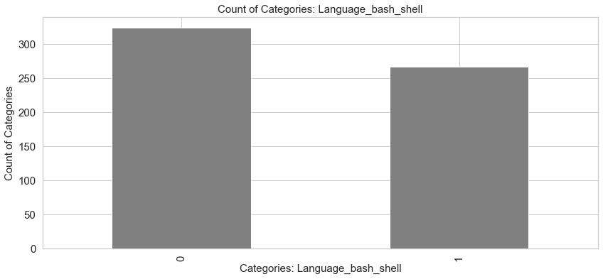

```
language_java
1    326
0    265
Name: language_java, dtype: int64
language_java total count:  591
```

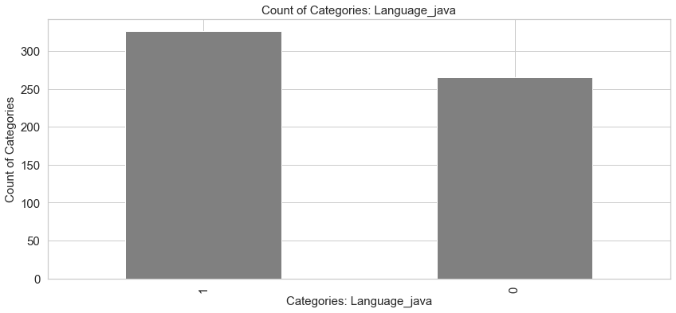

```
language_javascript
0    313
1    278
Name: language_javascript, dtype: int64
language_javascript total count:  591
```

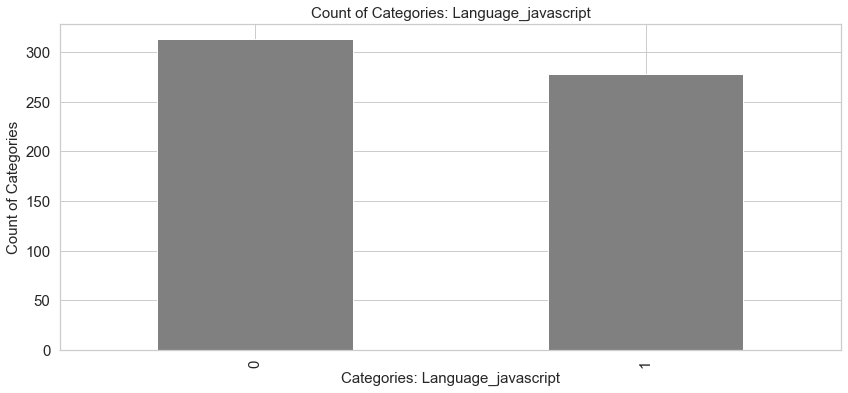

```
language_html_css
0    351
1    240
Name: language_html_css, dtype: int64
language_html_css total count:  591
```

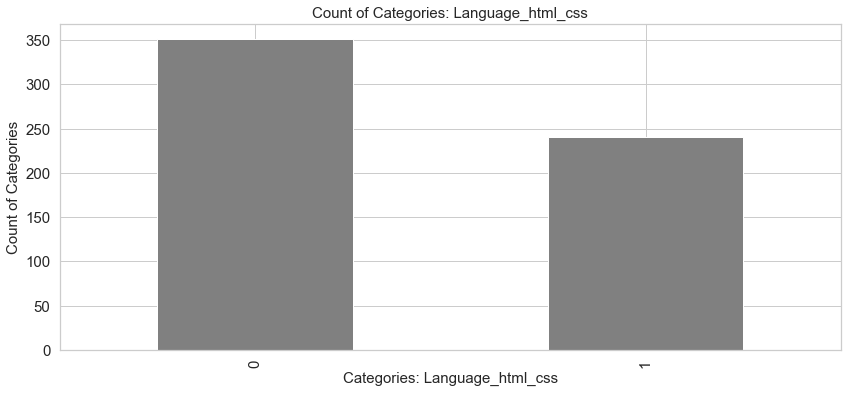

```
platform_aws
1    351
0    240
Name: platform_aws, dtype: int64
platform_aws total count:  591
```

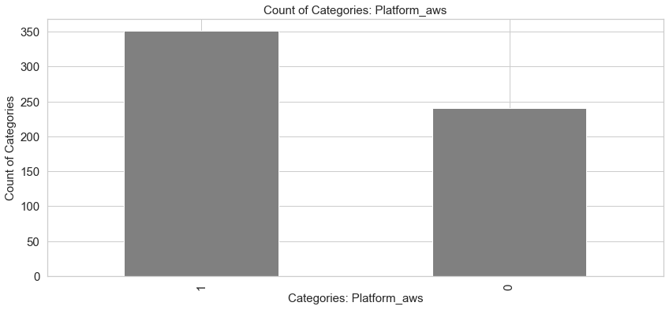

```
platform_gcp
0    426
1    165
Name: platform_gcp, dtype: int64
platform_gcp total count:  591
```

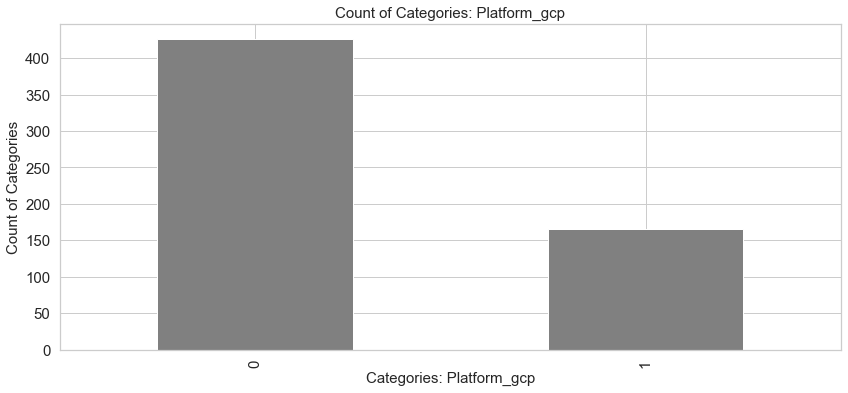

```
platform_azure
0    444
1    147
Name: platform_azure, dtype: int64
platform_azure total count:  591
```

[1 more figures not shown]

```python
# Provide count values for each categorical column.
for col in data[categorical_cols]:
    print(col)
    print(data[col].value_counts())
    print(col, 'total count: ', data[col].count())
    print('\n')

    # Bar chart count values for each categorical column.
    data[col].value_counts().sort_values(ascending=False).plot.bar(figsize=(14,6), fontsize = 15, color= 'grey')

    # Attributes of bar chart.
    plt.ylabel('Count of Categories', fontsize = 15)
    plt.xlabel('Categories: ' + col.capitalize(), fontsize = 15)
    plt.title('Count of Categories: ' + col.capitalize(), fontsize = 15)
    plt.show()
```

### 2. % of Rare Categories in Categorical Columns - Data & Chart

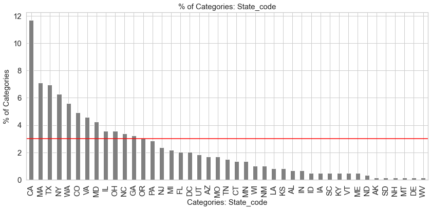

```
state_code
CA    11.68%
MA     7.11%
TX     6.94%
NY     6.26%
WA     5.58%
CO     4.91%
VA     4.57%
MD     4.23%
IL     3.55%
OH     3.55%
NC     3.38%
GA     3.21%
OR     3.05%
PA     2.88%
NJ     2.37%
MI      2.2%
FL     2.03%
DC     2.03%
UT     1.86%
AZ     1.69%
MO     1.69%
TN     1.52%
CT     1.35%
MN     1.35%
WI     1.02%
NM     1.02%
LA     0.85%
KS     0.85%
AL     0.68%
IN     0.68%
ME     0.51%
VT     0.51%
KY     0.51%
ID     0.51%
SC     0.51%
IA     0.51%
ND     0.34%
AK     0.17%
SD     0.17%
NH     0.17%
MT     0.17%
DE     0.17%
WV     0.17%
Name: state_code, dtype: object
```

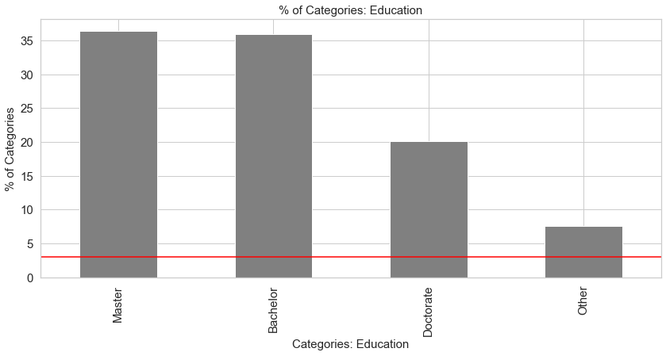

```
education
Master       36.38%
Bachelor     35.87%
Doctorate    20.14%
Other         7.61%
Name: education, dtype: object
```

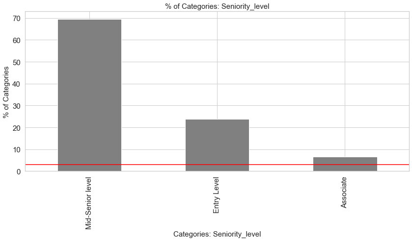

```
seniority_level
Mid-Senior level    69.54%
Entry Level         23.86%
Associate             6.6%
Name: seniority_level, dtype: object
```

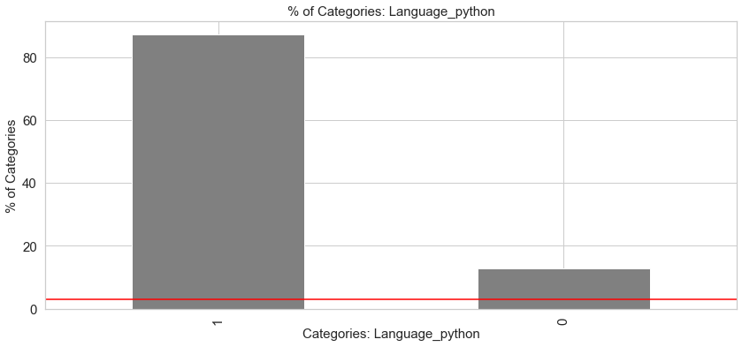

```
language_python
1    87.14%
0    12.86%
Name: language_python, dtype: object
```

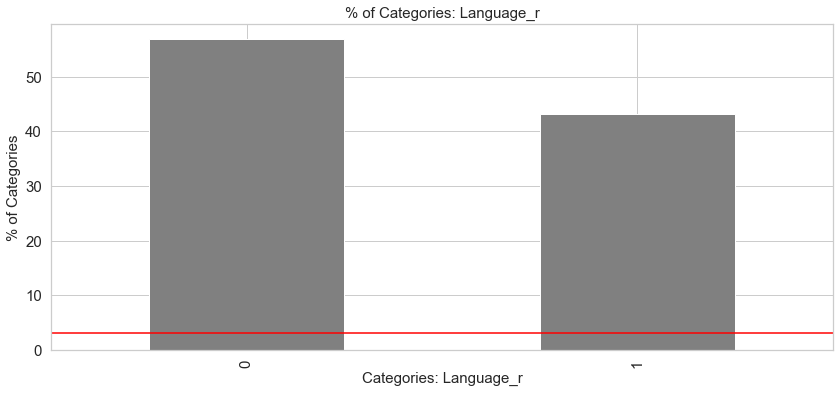

```
language_r
0    56.85%
1    43.15%
Name: language_r, dtype: object
```

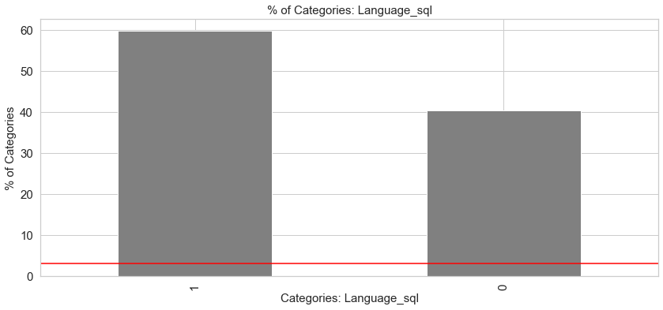

```
language_sql
1    59.73%
0    40.27%
Name: language_sql, dtype: object
```

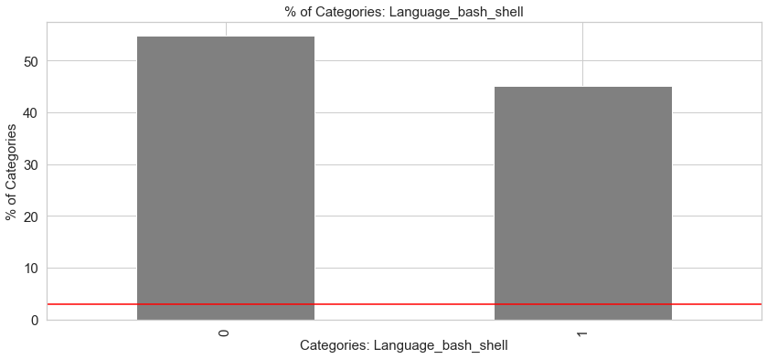

```
language_bash_shell
0    54.82%
1    45.18%
Name: language_bash_shell, dtype: object
```

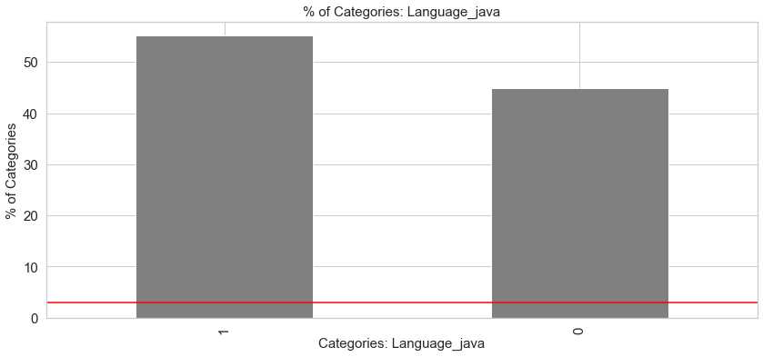

```
language_java
1    55.16%
0    44.84%
Name: language_java, dtype: object
```

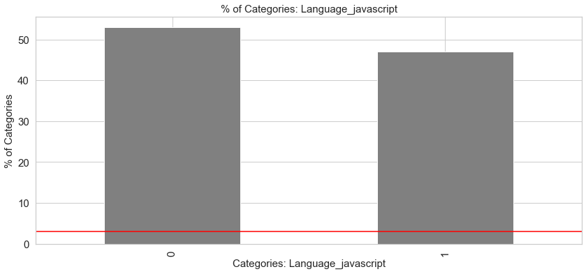

```
language_javascript
0    52.96%
1    47.04%
Name: language_javascript, dtype: object
```

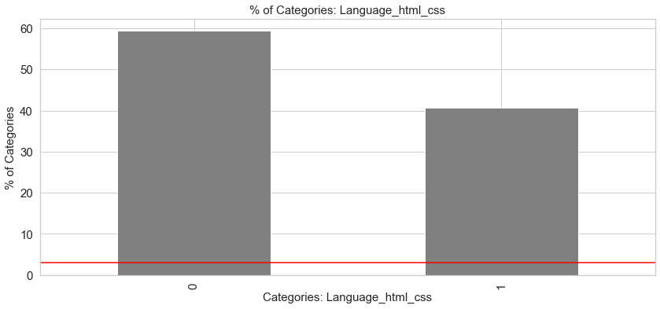

```
language_html_css
0    59.39%
1    40.61%
Name: language_html_css, dtype: object
```

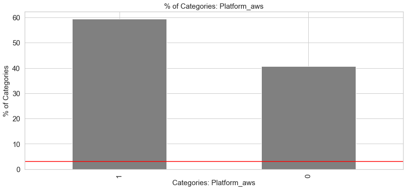

```
platform_aws
1    59.39%
0    40.61%
Name: platform_aws, dtype: object
```

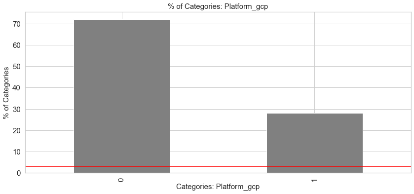

```
platform_gcp
0    72.08%
1    27.92%
Name: platform_gcp, dtype: object
```

[1 more figures not shown]

```
platform_azure
0    75.13%
1    24.87%
Name: platform_azure, dtype: object
```

```python
# Provide count values for each categorical column.
for col in data[categorical_cols]:
    # Bar chart % for each categorical column.
    ((data[col].value_counts()/data[col].shape[0])*100).sort_values(ascending=False).plot.bar(figsize=(14,6), color= 'grey', fontsize = 15)

    # Attributes of bar chart.
    plt.ylabel('% of Categories', fontsize = 15)
    plt.xlabel('Categories: ' + col.capitalize(), fontsize = 15)
    plt.title('% of Categories: ' + col.capitalize(), fontsize = 15)
    plt.axhline(y=3.0, color='red')
    plt.show()

    print(col)
    print(round(data[col].value_counts()/data[col].shape[0] * 100, 2).astype(str) + '%')
    print('\n')
```

### Analysis of Rare Categories

• state_code - California dominates with the highest developers. This seems mainly due to silicon valley. Only 13 states are dominantly based on a 3% threshold. All other states fall into the rare category.

• education - Highest number of developers have bachelors or masters. No education categories fall into the rare category.

• seniority_level – The highest number of developers are experienced. No seniority categories fall into the rare category.

• Other Columns - Other columns did not fall into rare category.

## Missing Values Steps:

### 1. Identifying Missing Values (nan) by Columns - Data & Chart

### 2. % of Missing Values by Columns - Data & Chart

### 3. Identifying 0 Values by Numerical Columns - Data & Chart

### 4. % of 0 Values by Numerical Columns - Data & Chart

### 1. Identifying Missing Values (nan) by Column - Data & Chart

```python
# Number of missing values for all columns.
data.isnull().sum()
```

```
response_id            0
state                  9
state_code             9
education              0
seniority_level        0
compensation           0
avg_age                0
language_python        0
language_r             0
language_sql           0
language_bash_shell    0
language_java          0
language_javascript    0
language_html_css      0
platform_aws           0
platform_gcp           0
platform_azure         0
dtype: int64
```

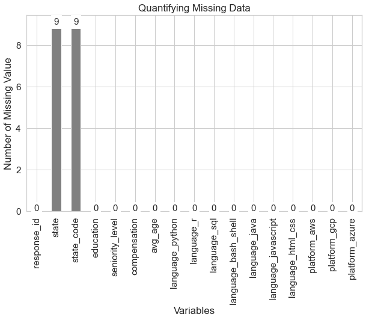

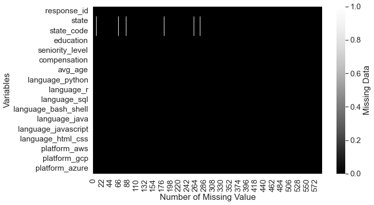

```python
# Bar chart for number of missing values for all columns.
## Value label function.
def add_value_label(x_list,y_list):
    for i in range(len(x_list)):
        plt.text(i,y_list[i],y_list[i], ha='center', fontsize = 15, bbox = dict(facecolor = 'white', alpha =1.0))

## Declare variable for x and y axis.
variables = data.columns
number_of_missing_values = data.isnull().sum()

## Attributes for bar chart.
bar_chart_missing_value = data.isnull().sum().plot.bar(figsize=(10,6), color= 'grey',
                                         ylabel = 'Number of Missing Value',
                                         xlabel = 'Variables',
                                         title = 'Quantifying Missing Data')

## Instantiate value label function.
add_value_label(variables, number_of_missing_values)

## Show the bar chart.
bar_chart_missing_value = plt.show()

# Heatmap for number of missing values for all columns.
sns.set(font_scale=1.4)
plt.figure(figsize=(10,6))

heatmap_missing_value = sns.heatmap(data.isnull().transpose(),
                        cmap="Greys_r",
                        cbar_kws={'label': 'Missing Data'})

heatmap_missing_value.set(xlabel='Number of Missing Value', ylabel='Variables')

heatmap_missing_value = plt.show()
```

### 2. % of Missing Values by Column - Data & Chart

```python
# % of missing values for all columns.
round((data.isnull().sum() / data.shape[0] * 100), 2).astype(str) + '%'
```

```
response_id             0.0%
state                  1.52%
state_code             1.52%
education               0.0%
seniority_level         0.0%
compensation            0.0%
avg_age                 0.0%
language_python         0.0%
language_r              0.0%
language_sql            0.0%
language_bash_shell     0.0%
language_java           0.0%
language_javascript     0.0%
language_html_css       0.0%
platform_aws            0.0%
platform_gcp            0.0%
platform_azure          0.0%
dtype: object
```

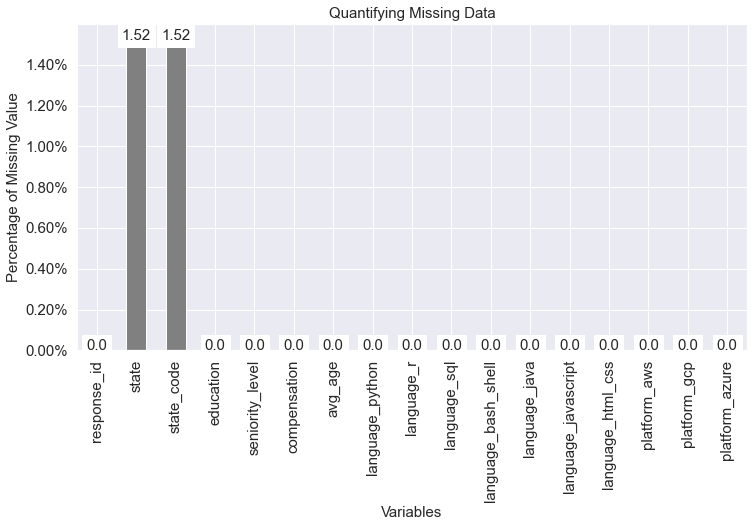

```python
# Bar chart for % of missing values for all columns.

## Value label function.
def add_value_label(x_list,y_list):
    for i in range(len(x_list)):
        plt.text(i,y_list[i],y_list[i], ha='center', fontsize = 15, bbox = dict(facecolor = 'white', alpha =1.0))

## Declare variable for x and y axis.
variables = data.columns
pect_of_missing_values = round((data.isnull().mean()*100),2)

## Attributes for bar chart.
ax = (data.isnull().mean()*100).plot.bar(figsize=(12,6), color= 'grey', fontsize = 15)
ax.yaxis.set_major_formatter(mtick.PercentFormatter())
plt.ylabel('Percentage of Missing Value', fontsize = 15)
plt.xlabel('Variables', fontsize = 15)
plt.title('Quantifying Missing Data', fontsize = 15)

## Instantiate value label function.
add_value_label(variables, pect_of_missing_values)
```

### 3. Identifying 0 Values by Numerical Columns - Data & Chart

```python
# Number of zero values for numerical columns.
(data[numerical_cols] == 0).sum(axis=0)
```

```
compensation    0
avg_age         6
dtype: int64
```

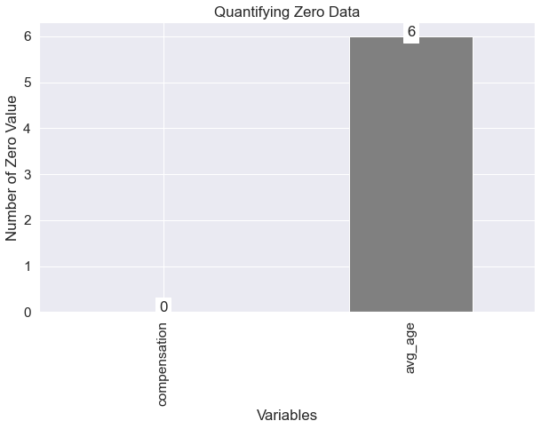

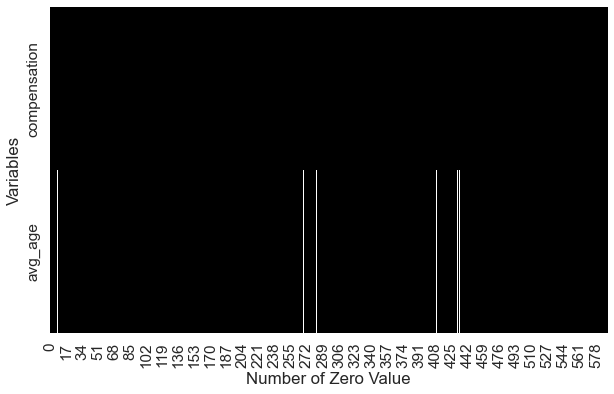

```python
# Bar chart for number of zero values for numerical columns.
## Value label function.
def add_value_label(x_list,y_list):
    for i in range(len(x_list)):
        plt.text(i,y_list[i],y_list[i], ha='center', bbox = dict(facecolor = 'white', alpha =1.0))

## Declare variable for x and y axis.
variables = data[numerical_cols].columns
number_of_zero_values = (data[numerical_cols] == 0).sum(axis=0)

## Attributes for bar chart.
bar_chart_zero_value = (data[numerical_cols] == 0).sum(axis=0).plot.bar(figsize=(10,6), color= 'grey',
                                         ylabel = 'Number of Zero Value',
                                         xlabel = 'Variables',
                                         title = 'Quantifying Zero Data')

## Instantiate value label function.
add_value_label(variables, number_of_zero_values)

## Show the bar chart.
bar_chart_zero_value = plt.show()

# Heatmap for number of missing values for all columns.
plt.figure(figsize=(10,6))

heatmap_zero_value = sns.heatmap((data[numerical_cols] == 0).transpose(), cmap="Greys_r", cbar=None)

heatmap_zero_value.set(xlabel='Number of Zero Value', ylabel='Variables')

heatmap_zero_value = plt.show()
```

### 4. % of 0 Values by Numerical Columns - Data & Chart

```python
# % of zero values for numerical columns.
round(((data[numerical_cols] == 0).sum(axis=0)/data.shape[0] * 100), 2).astype(str) + '%'
```

```
compensation     0.0%
avg_age         1.02%
dtype: object
```

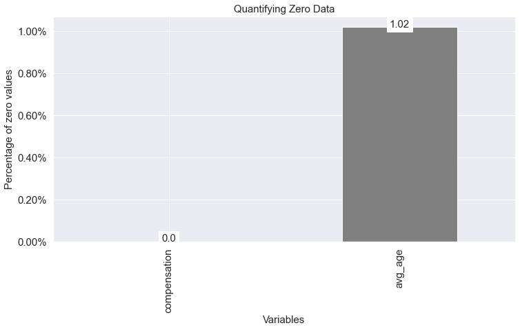

```python
# Bar chart for % of zero values for numerical columns.
## Value label function.
def add_value_label(x_list,y_list):
    for i in range(len(x_list)):
        plt.text(i,y_list[i],y_list[i], ha='center', fontsize = 15, bbox = dict(facecolor = 'white', alpha =1.0))

## Declare variable for x and y axis.
variables = data[numerical_cols].columns
pect_of_zero_values = round(((data[numerical_cols] == 0).sum(axis=0)/data.shape[0] * 100), 2)

## Attributes for bar chart.
ax = round(((data[numerical_cols] == 0).sum(axis=0)/data.shape[0] * 100), 2).plot.bar(figsize=(12,6), fontsize = 15, color= 'grey')
ax.yaxis.set_major_formatter(mtick.PercentFormatter())
plt.ylabel('Percentage of zero values', fontsize = 15)
plt.xlabel('Variables', fontsize = 15)
plt.title('Quantifying Zero Data', fontsize = 15)

## Instantiate value label function.
add_value_label(variables, pect_of_zero_values)
```

### Analysis of Missing Values

• Missing values by numerical columns - avg_age is the only column that has 0 values.